# Task 2.4

政委

10/28/2017

本任务希望训练大家掌握逻辑回归，决策树，随机森林等方法。首先，进入狗熊会公众号输入【非诚勿扰】，阅读这部分内容，了解数据的背景知识。同时阅读逻辑回归提供的资料学习。另外在狗熊会公众号中点击【人才培养】，进入【狗熊秘籍】，学习【视频微课】中的【机器学习】。最后，完成下面的题目。

- 各训练模型前，请通过`set.seed(1234)`设置随机种子，目的是让模型结果可重复出现。
- Q1:请导入数据。

```
##    吸引力偏好       真诚偏好        智力偏好        幽默偏好
##  Min.   : 0.00   Min.   : 0.00   Min.   : 2.00   Min.   : 0.0
##  1st Qu.:12.24   1st Qu.:15.00   1st Qu.:18.00   1st Qu.:15.0
##  Median :15.22   Median :20.00   Median :20.00   Median :18.0
##  Mean   :18.02   Mean   :18.22   Mean   :20.98   Mean   :17.3
##  3rd Qu.:20.00   3rd Qu.:20.00   3rd Qu.:25.00   3rd Qu.:20.0
##  Max.   :90.00   Max.   :60.00   Max.   :50.00   Max.   :40.0
##     雄心偏好        爱好偏好
##  Min.   : 0.00   Min.   : 0.00
##  1st Qu.:10.00   1st Qu.:10.00
##  Median :15.00   Median :13.21
##  Mean   :12.82   Mean   :12.66
##  3rd Qu.:16.67   3rd Qu.:16.00
##  Max.   :30.00   Max.   :30.00
```

```
##    吸引力打分       真诚打分         智力打分         幽默打分
##  Min.   : 0.00   Min.   : 0.000   Min.   : 0.000   Min.   : 0.000
##  1st Qu.: 5.00   1st Qu.: 6.000   1st Qu.: 7.000   1st Qu.: 5.000
##  Median : 6.00   Median : 7.000   Median : 8.000   Median : 6.000
##  Mean   : 5.92   Mean   : 7.047   Mean   : 7.361   Mean   : 6.152
##  3rd Qu.: 7.00   3rd Qu.: 8.000   3rd Qu.: 8.000   3rd Qu.: 8.000
##  Max.   :10.00   Max.   :10.000   Max.   :10.000   Max.   :10.000
##     雄心打分      共同爱好打分      吸引力得分        真诚得分
##  Min.   : 0.00   Min.   : 0.000   Min.   : 0.000   Min.   : 0.000
##  1st Qu.: 5.00   1st Qu.: 3.000   1st Qu.: 5.000   1st Qu.: 6.000
##  Median : 7.00   Median : 5.000   Median : 7.000   Median : 7.000
##  Mean   : 6.51   Mean   : 4.779   Mean   : 6.454   Mean   : 7.161
##  3rd Qu.: 8.00   3rd Qu.: 7.000   3rd Qu.: 8.000   3rd Qu.: 8.000
##  Max.   :10.00   Max.   :10.000   Max.   :10.000   Max.   :10.000
##     智力得分         幽默得分         雄心得分       共同爱好得分
##  Min.   : 0.000   Min.   : 0.000   Min.   : 0.000   Min.   : 0.000
##  1st Qu.: 6.000   1st Qu.: 5.000   1st Qu.: 5.000   1st Qu.: 4.000
##  Median : 7.000   Median : 7.000   Median : 6.000   Median : 5.000
##  Mean   : 7.198   Mean   : 6.408   Mean   : 6.192   Mean   : 5.007
##  3rd Qu.: 8.000   3rd Qu.: 8.000   3rd Qu.: 8.000   3rd Qu.: 7.000
##  Max.   :10.000   Max.   :11.000   Max.   :10.000   Max.   :10.000
##  决定
##  0:2540
##  1:1516
##
##
##
##
```

- Q2:`吸引力`，`爱好`，`雄心`，`幽默感`，`智力`，`真诚`变量分别表示在相亲前女性对于自己心仪男性在吸引力，爱好，雄心，幽默感，智力，真诚这六个方面的评分。请用雷达图展示。并进行分析和解读。Hint: 绘制雷达图，可借助fmsb包。

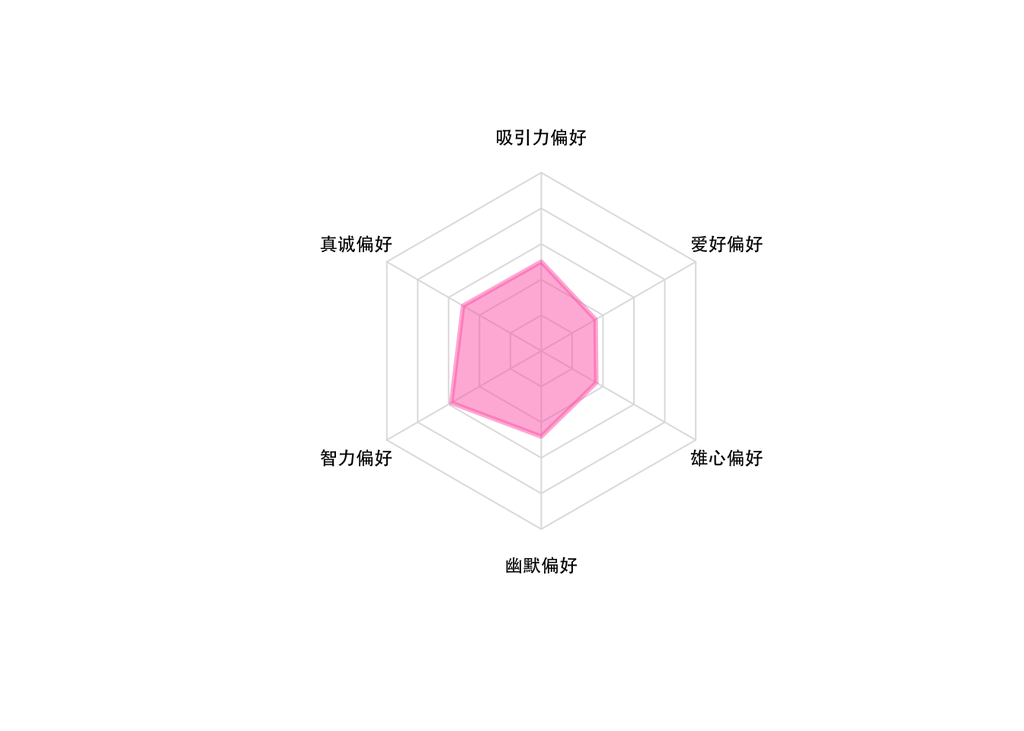

- Q3: 在相亲之后，女性对于约会的男性如果心仪会选择喜欢对方，并继续及接触，则变量`决定`=1;否则=0。例如逻辑回归分析结果如下。请解读该模型结果。Hint: 画ROC曲线，可借助pROC包。

```
##
## Call:
## glm(formula = 决定 ~ ., family = binomial(link = "logit"),
##     data = data_while_meeting)
##
## Deviance Residuals:
##     Min       1Q   Median       3Q      Max
## -2.3951  -0.8275  -0.3945   0.8853   2.8812
##
## Coefficients:
##              Estimate Std. Error z value Pr(>|z|)
## (Intercept)  -5.31518    0.29113 -18.257  < 2e-16 ***
## 吸引力打分    0.42231    0.02620  16.117  < 2e-16 ***
## 真诚打分      0.01573    0.02782   0.565    0.572
## 智力打分      0.05558    0.03143   1.768    0.077 .
## 幽默打分      0.27978    0.02595  10.782  < 2e-16 ***
## 雄心打分     -0.12684    0.01971  -6.434 1.24e-10 ***
## 共同爱好打分  0.12596    0.01694   7.435 1.05e-13 ***
## 吸引力得分   -0.17463    0.02445  -7.143 9.16e-13 ***
## 真诚得分      0.07061    0.02812   2.511    0.012 *
## 智力得分      0.04435    0.03105   1.429    0.153
## 幽默得分      0.03512    0.02569   1.367    0.172
## 雄心得分     -0.00698    0.02033  -0.343    0.731
## 共同爱好得分  0.02919    0.01781   1.639    0.101
## ---
## Signif. codes:  0 '***' 0.001 '**' 0.01 '*' 0.05 '.' 0.1 ' ' 1
##
## (Dispersion parameter for binomial family taken to be 1)
##
##     Null deviance: 5361.5  on 4055  degrees of freedom
## Residual deviance: 4116.7  on 4043  degrees of freedom
## AIC: 4142.7
##
## Number of Fisher Scoring iterations: 5
```

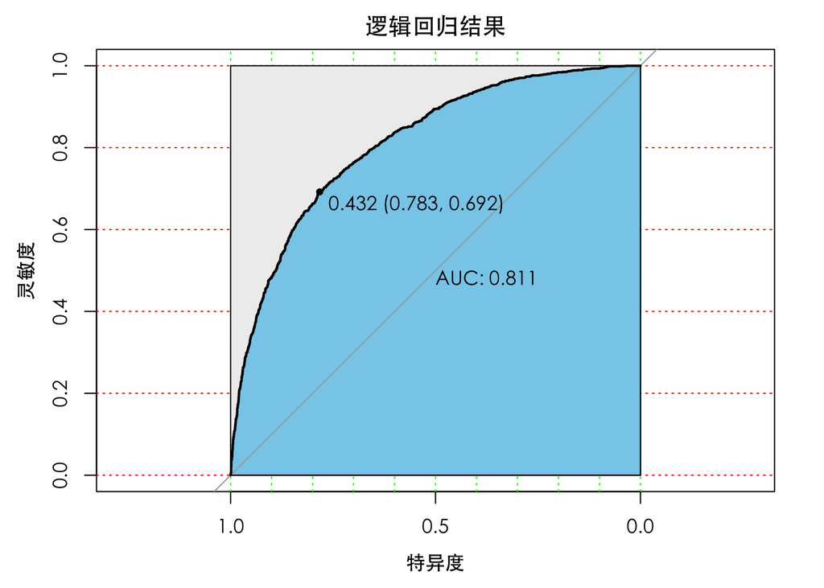

- Q4:利用决策树完成同样的上述分析。请解读该模型结果。Hint: 可视化模型，可借助rattle包。

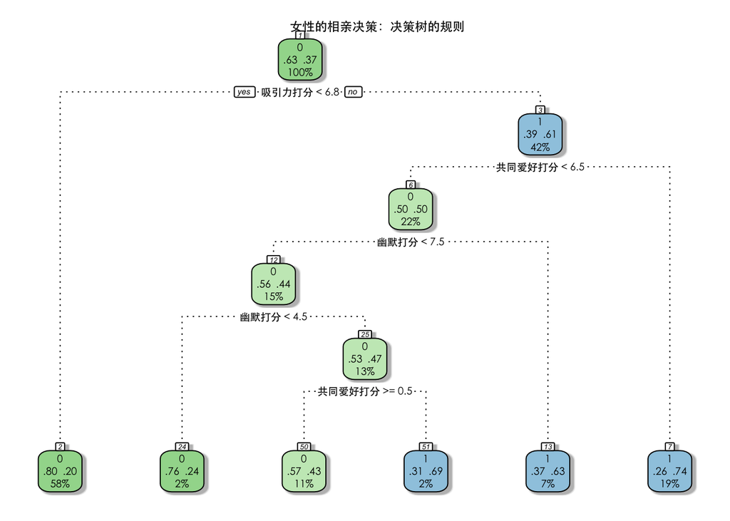

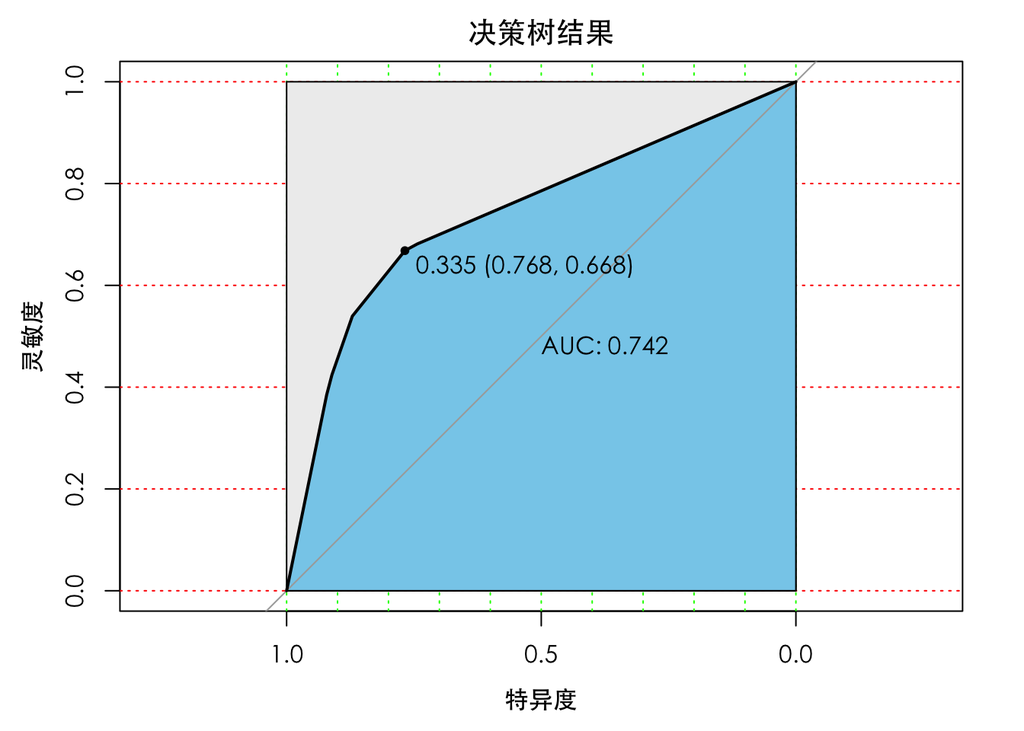

- Q5:利用随机森林完成同样的上述分析。请解读该模型结果。

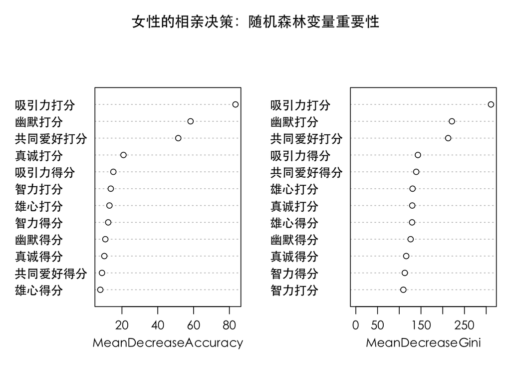

```
##                      0         1 MeanDecreaseAccuracy MeanDecreaseGini
## 吸引力打分   47.779744 79.184574            83.398149         311.0837
## 真诚打分     12.861532 15.440746            20.866211         129.8892
## 智力打分      8.615368  8.829902            13.779730         109.4154
## 幽默打分     43.713135 33.662121            58.309253         221.1067
## 雄心打分     19.737880 -5.969026            13.036278         130.6066
## 共同爱好打分 34.563970 36.070917            51.440988         212.5393
## 吸引力得分   11.260586  9.775372            15.212763         142.8772
## 真诚得分     10.787978  1.890308            10.172405         116.0110
## 智力得分      9.012284  7.486792            12.341846         112.7337
## 幽默得分      7.373034  6.301893            10.733559         126.1002
## 雄心得分      7.480477  2.796148             7.929639         129.4830
## 共同爱好得分  9.169817  2.429283             8.879058         139.0183
```

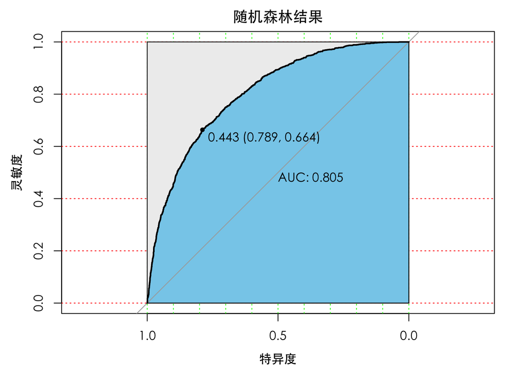